# A cluster analysis of recycling systems in England

Clare Gibson

# Setup

## Packages

Let’s load the required packages for this analysis.

```r
library(here)
library(tidyverse)
library(skimr)
library(corrplot)
library(tidytable)
library(janitor)
library(knitr)
```

## Collect the data

Let’s import the data and preview it.

```r
recycling <-
  read_csv(here("data/cln/data.csv"))

glimpse(recycling)
```

```
## Rows: 309
## Columns: 31
## $ lad21cd                     <chr> "E06000001", "E06000002", "E06000003", "E0…
## $ local_authority             <chr> "Hartlepool", "Middlesbrough", "Redcar and…
## $ in_lad                      <chr> "Y", "Y", "Y", "Y", "Y", "Y", "Y", "Y", "Y…
## $ wa21cd                      <chr> "E06000001", "E06000002", "E06000003", "E0…
## $ population                  <dbl> 92571, 143734, 136616, 197030, 108222, 128…
## $ collection_type             <chr> "Co-Mingled", "Co-Mingled", "Two Stream", …
## $ collection_type_sort        <dbl> 1, 1, 2, 3, 3, 1, 1, 2, 2, 1, 1, 3, 3, 3, …
## $ in_foi                      <chr> "Y", "Y", "Y", "Y", "Y", "Y", "Y", "Y", "Y…
## $ waste_authority             <chr> "Hartlepool Borough Council", "Middlesbrou…
## $ waste_authority_type        <chr> "Unitary", "Unitary", "Unitary", "Unitary"…
## $ total_collected             <dbl> 45400, 67649, 67283, 105430, 52638, 63344,…
## $ total_recycled              <dbl> 13264, 20557, 23107, 32635, 17080, 24560, …
## $ total_not_recycled          <dbl> 32136, 47092, 44177, 72794, 35559, 38783, …
```

[output cut: 18 more lines]

The dataset contains a large number of character columns. Let’s select only the columns we are interested in for this analysis.

```r
recycling <-
  recycling |>
  select(
    lad21cd,
    population,
    collection_type,
    household_collected,
    household_recycled,
    household_not_recycled,
    household_rejects
  )

head(recycling)
```

```
## # A tidytable: 6 × 7
##   lad21cd   population collection_type household_collected household_recycled
##   <chr>          <dbl> <chr>                         <dbl>              <dbl>
## 1 E06000001      92571 Co-Mingled                    39552              12893
## 2 E06000002     143734 Co-Mingled                    64433              19169
## 3 E06000003     136616 Two Stream                    57866              22077
## 4 E06000004     197030 Multi-Stream                  88050              22592
## 5 E06000005     108222 Multi-Stream                  46203              14968
## 6 E06000006     128577 Co-Mingled                    59958              22137
## # ℹ 2 more variables: household_not_recycled <dbl>, household_rejects <dbl>
```

Now we can check the summary statistics for each column and see if we have any missing values.

```r
skim(recycling)
```

Data summary

| Name | recycling |
| --- | --- |
| Number of rows | 309 |
| Number of columns | 7 |
| Key | NULL |
| _______________________ |  |
| Column type frequency: |  |
| character | 2 |
| numeric | 5 |
| ________________________ |  |
| Group variables | None |

**Variable type: character**

| skim_variable | n_missing | complete_rate | min | max | empty | n_unique | whitespace |
| --- | --- | --- | --- | --- | --- | --- | --- |
| lad21cd | 0 | 1 | 9 | 9 | 0 | 309 | 0 |
| collection_type | 0 | 1 | 10 | 12 | 0 | 3 | 0 |

**Variable type: numeric**

| skim_variable | n_missing | complete_rate | mean | sd | p0 | p25 | p50 | p75 | p100 | hist |
| --- | --- | --- | --- | --- | --- | --- | --- | --- | --- | --- |
| population | 0 | 1 | 182965.76 | 123691.45 | 2271 | 103617 | 142951 | 224826 | 1142494 | ▇▂▁▁▁ |
| household_collected | 0 | 1 | 73568.17 | 54141.93 | 1373 | 40697 | 55102 | 89832 | 401225 | ▇▂▁▁▁ |
| household_recycled | 0 | 1 | 30829.63 | 24491.44 | 553 | 17101 | 22933 | 34976 | 149880 | ▇▃▁▁▁ |
| household_not_recycled | 0 | 1 | 42738.56 | 33479.94 | 821 | 22191 | 31235 | 55777 | 309555 | ▇▂▁▁▁ |
| household_rejects | 0 | 1 | 1955.74 | 2390.31 | -866 | 544 | 1230 | 2479 | 19852 | ▇▁▁▁▁ |

We can see that there are no missing values in any of the columns. We notice that `household_rejects` has a some negative values, which doesn’t make sense. I propose to ignore that column for my analysis.

# Exploratory Analysis

## Correlations

Let’s run a correlation matrix to understand relationships between the variables.

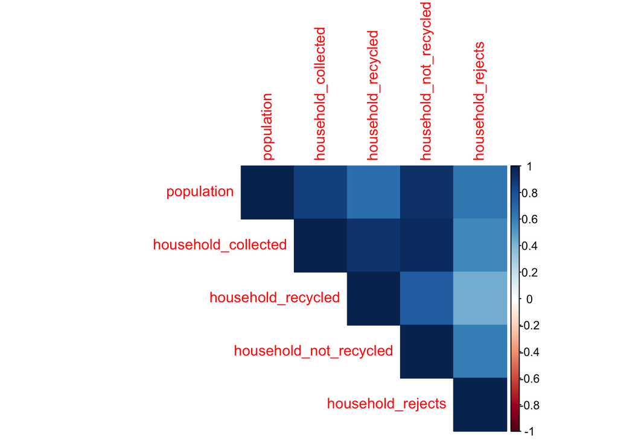

```r
recycling |>
  select(where(is.numeric)) |>
  cor(use = "pairwise.complete.obs") |>
  round(2) |>
  corrplot(method = "color", type = "upper")
```

There is a high correlation between `population` and `household_collected` meaning that as the population increases, so does the total amount of household waste that is collected. Same goes for `population` vs `household_not_recycled`. Both of these seem fairly obvious, so what if we look at the proportion of waste that is recycled instead of the amount? To do this we need to engineer a new feature into the dataset.

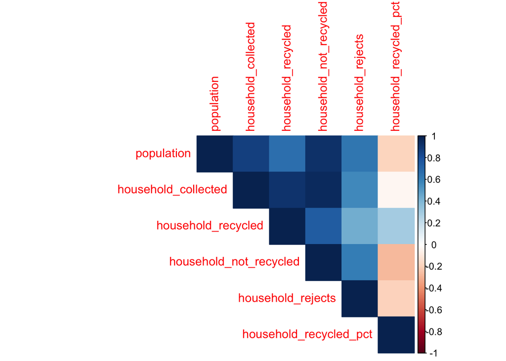

```r
recycling <-
  recycling |>
  mutate(
    household_recycled_pct = round(household_recycled / household_collected, 3)
  )

recycling |>
  select(where(is.numeric)) |>
  cor(use = "pairwise.complete.obs") |>
  round(2) |>
  corrplot(method = "color", type = "upper")
```

Now we see a negative correlation between `population` and `household_recycled_pct`, meaning that as population increases, the proportion of waste that is recycled decreases. Larger populations are associated with lower recycling rates.

Let’s explore this relationship in a scatterplot.

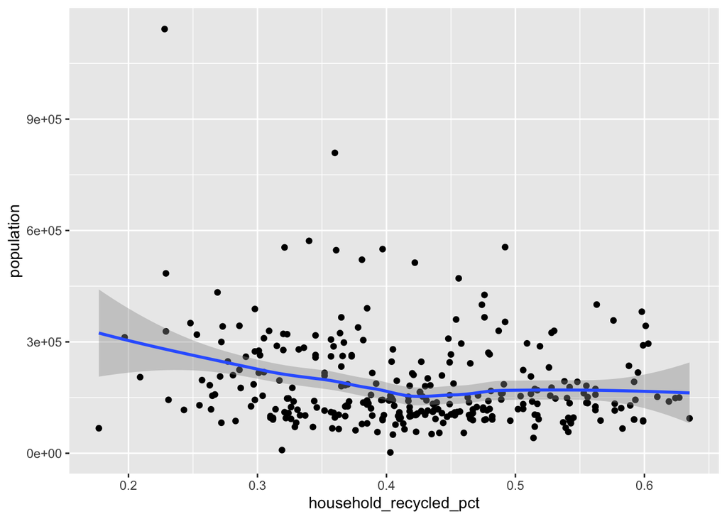

```r
recycling |>
  ggplot(
    aes(
      x = household_recycled_pct,
      y = population
    )
  ) +
  geom_point() +
  geom_smooth()
```

# Clustering

## Normalization

```r
scaled_recycling <-
  recycling |>
  select(where(is.numeric)) |>
  scale()
```

## Fit the model

```r
# Get the 2 columns of interest
scaled_recycling_2col <-
  scaled_recycling[, c("population", "household_recycled_pct")]

set.seed(123)
km.out <- kmeans(scaled_recycling_2col, centers = 3, nstart = 20)
km.out
```

```
## K-means clustering with 3 clusters of sizes 57, 115, 137
##
## Cluster means:
##   population household_recycled_pct
## 1  1.5274893             -0.7403150
## 2 -0.2386262              1.0287800
## 3 -0.4352181             -0.5555602
##
## Clustering vector:
##   [1] 3 3 3 3 3 3 3 3 3 2 2 3 2 3 1 1 2 1 3 2 1 2 1 2 2 1 3 3 3 3 3 3 1 2 2 2 3
##  [38] 2 2 2 1 3 1 2 1 2 2 2 1 3 1 3 1 1 1 2 1 1 1 2 2 3 2 2 3 3 3 3 3 2 3 3 3 2
##  [75] 3 2 2 2 2 3 2 2 2 2 2 2 3 3 3 2 2 2 2 3 2 3 2 2 3 2 2 3 2 2 2 2 3 2 2 3 3
## [112] 3 3 3 3 3 3 3 3 3 3 2 3 2 2 2 2 2 3 3 3 2 3 2 3 3 2 2 3 2 3 3 3 3 3 3 3 2
## [149] 2 2 3 3 3 3 3 2 3 3 3 3 3 3 3 3 3 2 3 3 3 3 3 3 2 3 3 2 3 3 3 3 3 3 3 3 2
## [186] 2 2 2 2 2 2 2 2 3 3 2 2 2 2 2 3 3 3 3 2 2 2 2 2 2 2 2 2 2 2 3 3 3 2 2 3 3
## [223] 2 3 2 3 3 3 3 3 3 3 3 2 2 2 3 3 3 2 2 2 1 2 2 2 2 2 2 2 3 1 3 1 1 2 1 2 1
## [260] 1 3 3 1 1 1 1 1 3 1 1 1 2 1 1 1 3 3 3 1 3 1 1 3 1 1 1 1 1 3 1 1 1 1 1 3 3
## [297] 2 1 1 3 1 1 3 1 2 1 1 1 3
##
## Within cluster sum of squares by cluster:
## [1] 114.98964  70.55520  69.72411
##  (between_SS / total_SS =  58.6 %)
##
## Available components:
##
## [1] "cluster"      "centers"      "totss"        "withinss"     "tot.withinss"
## [6] "betweenss"    "size"         "iter"         "ifault"
```

## Optimize the model

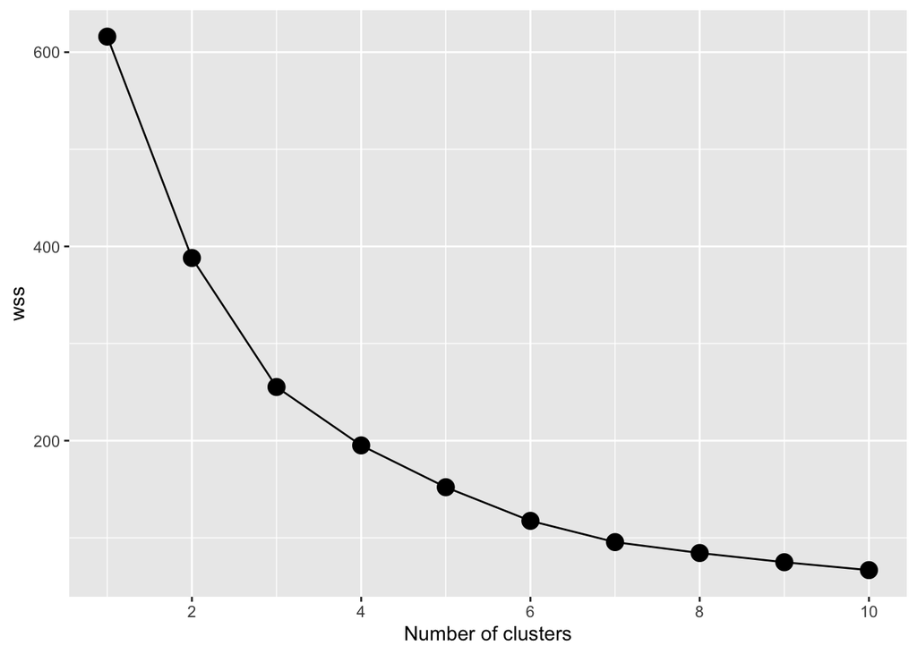

```r
# Decide how many clusters to look at
n_clusters <- 10

# Initialize total within sum of squares error: wss
wss <- numeric(n_clusters)

set.seed(123)

# Look over 1 to n possible clusters
for (i in 1:n_clusters) {
  # Fit the model
  km.out <- kmeans(scaled_recycling_2col, centers = i, nstart = 20)
  # Save the within cluster sum of squares
  wss[i] <- km.out$tot.withinss
}

# Produce a scree plot
wss_df <- tibble(clusters = 1:n_clusters, wss = wss)

scree_plot <- ggplot(wss_df, aes(x = clusters, y = wss, group = 1)) +
  geom_point(size = 4) +
  geom_line() +
  scale_x_continuous(breaks = c(2, 4, 6, 8, 10)) +
  xlab("Number of clusters")

scree_plot
```

## Rebuild the model with optimized k

```r
k <- 6

set.seed(123)

km.out <- kmeans(scaled_recycling_2col, centers = k, nstart = 20)
```

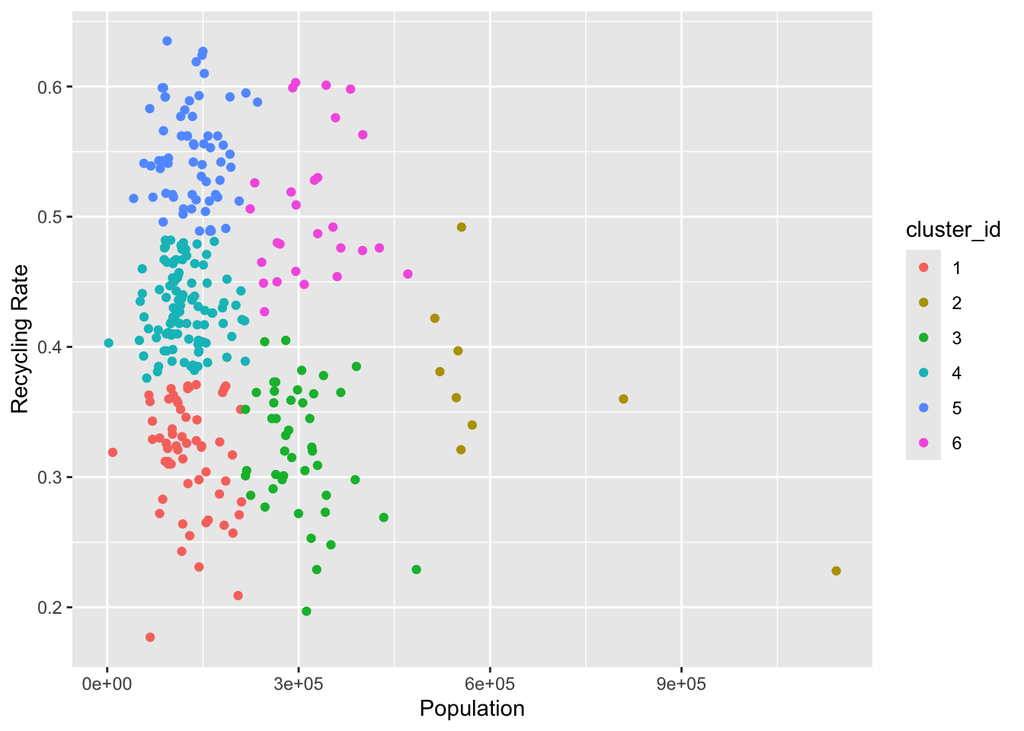

```r
recycling$cluster_id <- factor(km.out$cluster)

ggplot(
  recycling,
  aes(
    x = population,
    y = household_recycled_pct,
    colour = cluster_id
  )
) +
  geom_point() +
  xlab("Population") +
  ylab("Recycling Rate")
```

# Interpret the results

First, we dummy code the only categorical feature, `collection_type` to allow us to get descriptive statistics for the values of this feature.

```r
# Get dummies
recycling <-
  recycling |>
  get_dummies(cols = collection_type) |>
  select(!collection_type) |>
  clean_names()

# Summarise descriptive stats of full data
recycling_stats <-
  recycling |>
  summarise(
    global_comingled = mean(collection_type_co_mingled),
    global_two_stream = mean(collection_type_two_stream),
    global_multi_stream = mean(collection_type_multi_stream),
    global_population = median(population),
    global_household_collected = median(household_collected),
    global_household_recycled = median(household_recycled),
    global_household_rate = median(household_recycled_pct)
  ) |>
  round(2)

recycling_stats |>
  kable()
```

| global_comingled | global_two_stream | global_multi_stream | global_population | global_household_collected | global_household_recycled | global_household_rate |
| --- | --- | --- | --- | --- | --- | --- |
| 0.51 | 0.36 | 0.13 | 142951 | 55102 | 22933 | 0.42 |

Next get the same descriptive stats but grouped by cluster.

```r
recycling_stats_by_cluster <-
  recycling |>
  group_by(cluster_id) |>
  summarise(
    cluster_comingled = round(mean(collection_type_co_mingled), 2),
    cluster_two_stream = round(mean(collection_type_two_stream), 2),
    cluster_multi_stream = round(mean(collection_type_multi_stream), 2),
    cluster_population = median(population),
    cluster_household_collected = median(household_collected),
    cluster_household_recycled = median(household_recycled),
    cluster_household_rate = median(household_recycled_pct)
  )

recycling_stats_by_cluster |>
  kable()
```

| cluster_id | cluster_comingled | cluster_two_stream | cluster_multi_stream | cluster_population | cluster_household_collected | cluster_household_recycled | cluster_household_rate |
| --- | --- | --- | --- | --- | --- | --- | --- |
| 1 | 0.56 | 0.36 | 0.08 | 123383.0 | 45807 | 14587 | 0.3240 |
| 2 | 0.22 | 0.67 | 0.11 | 554401.0 | 239199 | 92163 | 0.3610 |
| 3 | 0.69 | 0.24 | 0.07 | 289254.0 | 107383 | 34901 | 0.3200 |
| 4 | 0.47 | 0.39 | 0.15 | 113047.0 | 45328 | 19781 | 0.4270 |
| 5 | 0.52 | 0.30 | 0.18 | 135062.5 | 51970 | 28780 | 0.5425 |
| 6 | 0.33 | 0.52 | 0.15 | 308705.0 | 127334 | 62984 | 0.4870 |

Let’s plot the differences from the population for each cluster.

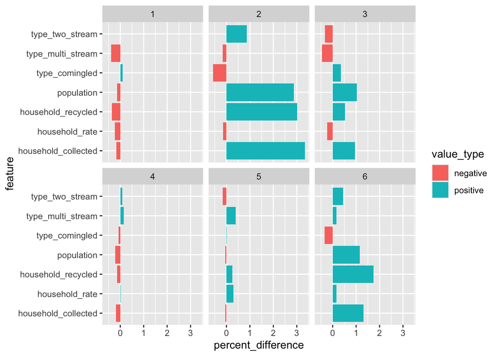

```r
recycling_cluster_profiles <-
  recycling_stats_by_cluster |>
  bind_cols(recycling_stats) |>
  # Calculate the difference from global for each cluster
  mutate(
    type_comingled = (cluster_comingled - global_comingled) / global_comingled,
    type_two_stream = (cluster_two_stream - global_two_stream) / global_two_stream,
    type_multi_stream = (cluster_multi_stream - global_multi_stream) / global_multi_stream,
    population = (cluster_population - global_population) / global_population,
    household_collected = (cluster_household_collected - global_household_collected) / global_household_collected,
    household_recycled = (cluster_household_recycled - global_household_recycled) / global_household_recycled,
    household_rate = (cluster_household_rate - global_household_rate) / global_household_rate
  ) |>
  select(cluster_id, type_comingled, type_two_stream, type_multi_stream, population,
         household_collected, household_recycled, household_rate) |>
  pivot_longer(cols = !cluster_id, names_to = "feature", values_to = "percent_difference") |>
  mutate(value_type = if_else(percent_difference >= 0, "positive", "negative"))

recycling_cluster_profiles |>
  ggplot(aes(x = percent_difference, y = feature, fill = value_type)) +
  geom_col() +
  facet_wrap(~cluster_id, scales = "fixed")
```